# Porites_DEG

LM Gorman, AS Huffmyer

2025-03-26

# Set up

Set up workspace, set options, and load required packages.

```r
knitr::opts_chunk$set(echo = TRUE, warning = FALSE, message = FALSE)
```

Load libraries.

```r
options(stringsAsFactors = FALSE)
#if ("tidyverse" %in% rownames(installed.packages()) == 'FALSE') install.packages('tidyverse')
#if ("genefilter" %in% rownames(installed.packages()) == 'FALSE') install.packages('genefilter')
#if ("RColorBrewer" %in% rownames(installed.packages()) == 'FALSE') install.packages('RColorBrewer')
#if ("WGCNA" %in% rownames(installed.packages()) == 'FALSE') install.packages('WGCNA')
#if ("flashClust" %in% rownames(installed.packages()) == 'FALSE') install.packages('flashClust')
#if ("gridExtra" %in% rownames(installed.packages()) == 'FALSE') install.packages('gridExtra')
#if ("ComplexHeatmap" %in% rownames(installed.packages()) == 'FALSE') BiocManager::install("ComplexHeatmap")
#if ("DESeq2" %in% rownames(installed.packages()) == 'FALSE') BiocManager::install("DESeq2")
#if ("goseq" %in% rownames(installed.packages()) == 'FALSE') BiocManager::install("goseq")
#if ("dplyr" %in% rownames(installed.packages()) == 'FALSE') install.packages('dplyr')
#if ("clusterProfiler" %in% rownames(installed.packages()) == 'FALSE') BiocManager::install("clusterProfiler")
#if ("pheatmap" %in% rownames(installed.packages()) == 'FALSE') install.packages('pheatmap')
#if ("magrittr" %in% rownames(installed.packages()) == 'FALSE') install.packages('magrittr')
#if ("rtracklayer" %in% rownames(installed.packages()) == 'FALSE') BiocManager::install("rtracklayer")
#if ("GenomicRanges" %in% rownames(installed.packages()) == 'FALSE') BiocManager::install("GenomicRanges")
#if ("plyranges" %in% rownames(installed.packages()) == 'FALSE') BiocManager::install("plyranges")
#if ("GSEABase" %in% rownames(installed.packages()) == 'FALSE') BiocManager::install("GSEABase")
#if ("GOSim" %in% rownames(installed.packages()) == 'FALSE') BiocManager::install("GOSim")
#if ("stats" %in% rownames(installed.packages()) == 'FALSE') install.packages("stats")
#if ("ggdendro" %in% rownames(installed.packages()) == 'FALSE') BiocManager::install("ggdendro")
#if ("GO.db" %in% rownames(installed.packages()) == 'FALSE') BiocManager::install("GO.db")
#if ("rrvgo" %in% rownames(installed.packages()) == 'FALSE') BiocManager::install("rrvgo")
#if ("viridis" %in% rownames(installed.packages()) == 'FALSE') install.packages("viridis")
#if ("topGO" %in% rownames(installed.packages()) == 'FALSE') BiocManager::install("topGO")
#if ("biomaRt" %in% rownames(installed.packages()) == 'FALSE') BiocManager::install("biomaRt")
#if ("Rgraphviz" %in% rownames(installed.packages()) == 'FALSE') BiocManager::install("Rgraphviz")
#if ("EnhancedVolcano" %in% rownames(installed.packages()) == 'FALSE') BiocManager::install("EnhancedVolcano")
#if ("vegan" %in% rownames(installed.packages()) == 'FALSE') install.packages("vegan")
#if ("factoextra" %in% rownames(installed.packages()) == 'FALSE') install.packages("factoextra")

library("vegan")
library("factoextra")
library("viridis")
library("DESeq2")
library("tidyverse")
library("genefilter")
library("RColorBrewer")
#library("WGCNA")
library("flashClust")
library("gridExtra")
library("ComplexHeatmap")
library("goseq")
library("dplyr")
library("clusterProfiler")
library("pheatmap")
library("magrittr")
library("rtracklayer")
library("GenomicRanges")
library("plyranges")
library("GSEABase")
library("GOSim")
library("stats")
library("ggdendro")
library("GO.db")
library("rrvgo")
library("cowplot")
library("topGO")
library("biomaRt")
library("Rgraphviz")
library("EnhancedVolcano")
```

# Sample mapping

This table shows the total number of mapped reads of each sample of our samples to the *Porites evermanni* genome from the Palumbi lab - available at: https://www.genoscope.cns.fr/corals/genomes.html

```r
porites_mapping <- tribble(
  ~treatment, ~sample_id, ~total_mapped_reads, ~total_primary_reads, ~total_percent_mapped, ~primary_percent_mapped,
  "Porites sp. eaten", "225R", 2907570, 2534398, 4.43, 3.88,
  "Porites sp. eaten", "235R", 211878608, 143543886, 97.26, 96.01,
  "Porites sp. eaten", "43R", 12644158, 8762710, 9.78, 6.99,
  "Porites sp. eaten", "211R_subset", 219954702, 155192096, 89.86, 86.22,
  "Porites sp. eaten", "218R", 183856720, 126776572, 96.73, 95.33,
  "Porites sp. eaten", "34R", 1022532, 783544, 1.37, 1.05,
  "Porites sp. eaten", "227R", 171417626, 127096866, 84.19, 79.79,
  "Porites sp. eaten", "16R", 9932412, 8301790, 6.14, 5.18,
  "Porites sp. control", "61R", 156888590, 112220878, 91.65, 88.70,
  "Porites sp. control", "86R", 172716586, 119000396, 97.33, 96.17,
  "Porites sp. control", "236R", 212095574, 152349478, 96.43, 95.10,
  "Porites sp. control", "244R", 188686986, 129969490, 94.76, 92.57,
  "Porites sp. control", "82R", 198766054, 131310576, 98.85, 98.26,
  "Porites sp. control", "71R", 190552052, 127166612, 95.40, 93.26,
  "Porites sp. control", "253R", 195777140, 141597122, 97.66, 96.80,
  "Porites sp. control", "76R", 207617046, 141609686, 95.93, 94.14
  )

#Filter based on samples <5 million mapped and/or primary reads
 porites_mapping %>%
  filter(total_mapped_reads < 5000000)
```

```
## # A tibble: 2 × 6
##   treatment         sample_id total_mapped_reads total_primary_reads
##   <chr>             <chr>                  <dbl>               <dbl>
## 1 Porites sp. eaten 225R                 2907570             2534398
## 2 Porites sp. eaten 34R                  1022532              783544
## # ℹ 2 more variables: total_percent_mapped <dbl>, primary_percent_mapped <dbl>
```

```r
porites_mapping %>%
  filter(total_primary_reads < 5000000)
```

```
## # A tibble: 2 × 6
##   treatment         sample_id total_mapped_reads total_primary_reads
##   <chr>             <chr>                  <dbl>               <dbl>
## 1 Porites sp. eaten 225R                 2907570             2534398
## 2 Porites sp. eaten 34R                  1022532              783544
## # ℹ 2 more variables: total_percent_mapped <dbl>, primary_percent_mapped <dbl>
```

Samples 225R and 34R have < 5000000 reads in primary and total mapped reads

```r
#Make the table in descending order of total mapped reads
porites_mapping %>%
  #arrange(desc(total_mapped_reads)) %>%
  knitr::kable(caption = "Total mapped reads  from each sample to *Porites evermanni* genome.", col.names = c("Treatment", "ID", "Total number of mapped reads", "Number of primary mapped reads", "Total % mapped", "Primary % mapped"))
```

Total mapped reads from each sample to *Porites evermanni* genome.

| Treatment | ID | Total number of mapped reads | Number of primary mapped reads | Total % mapped | Primary % mapped |
| --- | --- | --- | --- | --- | --- |
| Porites sp. eaten | 225R | 2907570 | 2534398 | 4.43 | 3.88 |
| Porites sp. eaten | 235R | 211878608 | 143543886 | 97.26 | 96.01 |
| Porites sp. eaten | 43R | 12644158 | 8762710 | 9.78 | 6.99 |
| Porites sp. eaten | 211R_subset | 219954702 | 155192096 | 89.86 | 86.22 |
| Porites sp. eaten | 218R | 183856720 | 126776572 | 96.73 | 95.33 |
| Porites sp. eaten | 34R | 1022532 | 783544 | 1.37 | 1.05 |
| Porites sp. eaten | 227R | 171417626 | 127096866 | 84.19 | 79.79 |
| Porites sp. eaten | 16R | 9932412 | 8301790 | 6.14 | 5.18 |
| Porites sp. control | 61R | 156888590 | 112220878 | 91.65 | 88.70 |
| Porites sp. control | 86R | 172716586 | 119000396 | 97.33 | 96.17 |
| Porites sp. control | 236R | 212095574 | 152349478 | 96.43 | 95.10 |
| Porites sp. control | 244R | 188686986 | 129969490 | 94.76 | 92.57 |
| Porites sp. control | 82R | 198766054 | 131310576 | 98.85 | 98.26 |
| Porites sp. control | 71R | 190552052 | 127166612 | 95.40 | 93.26 |
| Porites sp. control | 253R | 195777140 | 141597122 | 97.66 | 96.80 |
| Porites sp. control | 76R | 207617046 | 141609686 | 95.93 | 94.14 |

```r
#Colour the cells <5 million
library(htmlTable)
#indices defining where the styles go
where_p <- rbind(c(1, 3), c(1, 4), c(6,3), c(6,4))
style_p <- c('background-color: red; color: white;',
           'background-color: red; color: white;',
           'background-color: red; color: white;',
           'background-color: red; color: white;'
           )

css.cell <- matrix('', nrow(porites_mapping), ncol(porites_mapping))
css.cell[where_p] <- style_p
htmlTable(porites_mapping, css.cell = css.cell, dimnames = NULL, c("Treatment", "ID", "Total number of mapped reads", "Number of primary mapped reads", "Total % mapped", "Primary % mapped"))
```

|  | Treatment | ID | Total number of mapped reads | Number of primary mapped reads | Total % mapped | Primary % mapped |
| --- | --- | --- | --- | --- | --- | --- |
| 1 | Porites sp. eaten | 225R | 2907570 | 2534398 | 4.43 | 3.88 |
| 2 | Porites sp. eaten | 235R | 211878608 | 143543886 | 97.26 | 96.01 |
| 3 | Porites sp. eaten | 43R | 12644158 | 8762710 | 9.78 | 6.99 |
| 4 | Porites sp. eaten | 211R_subset | 219954702 | 155192096 | 89.86 | 86.22 |
| 5 | Porites sp. eaten | 218R | 183856720 | 126776572 | 96.73 | 95.33 |
| 6 | Porites sp. eaten | 34R | 1022532 | 783544 | 1.37 | 1.05 |
| 7 | Porites sp. eaten | 227R | 171417626 | 127096866 | 84.19 | 79.79 |
| 8 | Porites sp. eaten | 16R | 9932412 | 8301790 | 6.14 | 5.18 |
| 9 | Porites sp. control | 61R | 156888590 | 112220878 | 91.65 | 88.7 |
| 10 | Porites sp. control | 86R | 172716586 | 119000396 | 97.33 | 96.17 |
| 11 | Porites sp. control | 236R | 212095574 | 152349478 | 96.43 | 95.1 |
| 12 | Porites sp. control | 244R | 188686986 | 129969490 | 94.76 | 92.57 |
| 13 | Porites sp. control | 82R | 198766054 | 131310576 | 98.85 | 98.26 |
| 14 | Porites sp. control | 71R | 190552052 | 127166612 | 95.4 | 93.26 |
| 15 | Porites sp. control | 253R | 195777140 | 141597122 | 97.66 | 96.8 |
| 16 | Porites sp. control | 76R | 207617046 | 141609686 | 95.93 | 94.14 |

```r
porites_mapping %>%
  filter(!(sample_id == c("34R", "225R"))) %>% #remove 34R and 225R
  group_by(treatment) %>%
  summarise(mean_total_mapped = mean(total_mapped_reads), mean_primary_mapped = mean(total_primary_reads))
```

```
## # A tibble: 2 × 3
##   treatment           mean_total_mapped mean_primary_mapped
##   <chr>                           <dbl>               <dbl>
## 1 Porites sp. control        190387504.          131903030.
## 2 Porites sp. eaten          101701791            71623983.
```

Similar to *Acropora* data, samples for control nearly have double the mapped reads of the eaten samples.

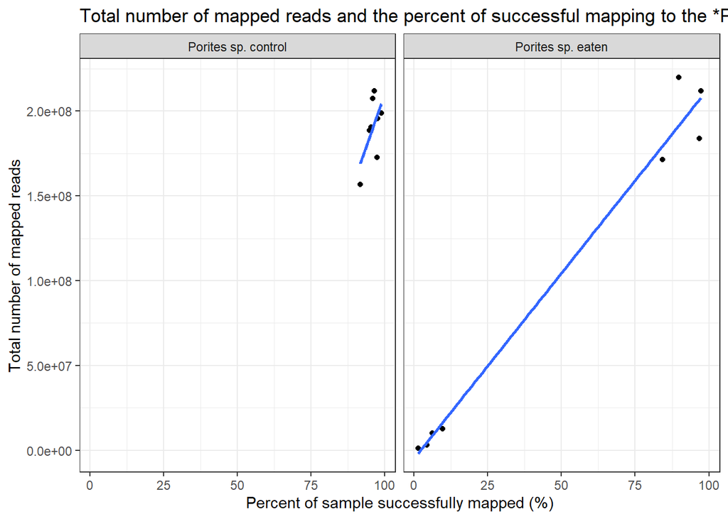

```r
porites_mapping %>%
  ggplot(aes(total_percent_mapped, total_mapped_reads)) +
  geom_point() +
  facet_wrap(~treatment) +
  geom_smooth(method = 'lm', se = FALSE) +
  labs(title = "Total number of mapped reads and the percent of successful mapping to the *Porites evermanni* genome", x = "Percent of sample successfully mapped (%)", y = "Total number of mapped reads") +
  theme_bw()
```

You can see that the *Porites* sp. control samples have a much lower variability in the total number of mapped reads and those successfully mapped whereas the *Porites* sp. eaten treatment have a large range of both total reads and those successfully mapped. The general pattern shows that the more reads a sample has overall, the more that successfully mapped to the *Porites evermanni* genome.

# Load and format data

Load metadata

```r
metadata_por <- read.csv("data/metadata_porites.csv", header = TRUE, sep = ",")%>%dplyr::select(sample, eatenvscontrol, code)
metadata_por$code<-paste0(metadata_por$code)
head(metadata_por)
```

```
##          sample eatenvscontrol      code
## 1  trim.16R.gtf          eaten Por_eaten
## 2 trim.211R.gtf          eaten Por_eaten
## 3 trim.218R.gtf          eaten Por_eaten
## 4 trim.225R.gtf          eaten Por_eaten
## 5 trim.227R.gtf          eaten Por_eaten
## 6 trim.235R.gtf          eaten Por_eaten
```

Load Porites gene count matrix generated from stringtie

```r
gcount_por <- as.data.frame(read.csv("data/gene-count-matrix/porites_gene_count_matrix.csv", row.names="gene_id"), colClasses = double)
head(gcount_por)
```

```
##               trim.16R.gtf trim.211R.gtf trim.218R.gtf trim.225R.gtf
## Peve_00020601            0          2459          1494             0
## Peve_00010391            0           107            26             0
## Peve_00010390            0             0            19             0
## Peve_00010393            0             7             0             0
## Peve_00010392            0           334           112             0
## Peve_00010395            0             0             0             0
##               trim.227R.gtf trim.235R.gtf trim.236R.gtf trim.244R.gtf
## Peve_00020601          3826             0          1415           883
## Peve_00010391            68             0            11           138
## Peve_00010390            52             0             0             0
## Peve_00010393            40            50            93             0
## Peve_00010392           362             0            38           108
## Peve_00010395             0             0             0             0
##               trim.253R.gtf trim.34R.gtf trim.43R.gtf trim.61R.gtf trim.71R.gtf
## Peve_00020601          1263            0            0         1157          533
## Peve_00010391            24            0            0            0            0
## Peve_00010390             0            0            0            0            0
## Peve_00010393            48            0            0            0            0
## Peve_00010392            75            0            0          122            0
## Peve_00010395             0            0            0            0            0
##               trim.76R.gtf trim.82R.gtf trim.86R.gtf
## Peve_00020601          605          127          771
## Peve_00010391            0            0           14
## Peve_00010390            0            0            0
## Peve_00010393           35            0            0
## Peve_00010392            0            0           78
## Peve_00010395            0            0            0
```

```r
#Check that there are no genes with 0 counts across all samples (remember only 16 columns since we are just looking at Porites).
dim(gcount_por)
```

```
## [1] 40389    16
```

```r
gcount_por<-gcount_por %>%
  mutate(Total = rowSums(.[, 1:16]))%>%
  filter(!Total==0)%>%
  dplyr::select(!Total)
dim(gcount_por)
```

```
## [1] 35599    16
```

Started with 40389 and ended with 35599 genes after removing 0’s.

# Filtering using pOverA

```r
#Create filter for the counts data
filt_por <- filterfun(pOverA(0.5,10))
gfilt_por <- genefilter(gcount_por, filt_por)
#identify genes to keep by count filter
gkeep_por <- gcount_por[gfilt_por,]
#identify gene lists
gn.keep_por <- rownames(gkeep_por)
#gene count data filtered in PoverA, P percent of the samples have counts over A
gcount_filt_por <- as.data.frame(gcount_por[which(rownames(gcount_por) %in% gn.keep_por),])

#How many rows do we have before and after filtering?
nrow(gcount_por) #Before
```

```
## [1] 35599
```

```r
nrow(gcount_filt_por) #After
```

```
## [1] 16279
```

We had 35599 genes before filtering and have 16279 genes after filtering.

```r
# Function to extract 'R' followed by numbers from column names
extract_R_numbers_por <- function(col_names) {
  sub("R(\\d+).*", "\\1", col_names)
}
# Apply the function to all column names
new_col_names_por <- sapply(names(gcount_filt_por), extract_R_numbers_por)
# Output the modified dataframe
names(gcount_filt_por)
```

```
##  [1] "trim.16R.gtf"  "trim.211R.gtf" "trim.218R.gtf" "trim.225R.gtf"
##  [5] "trim.227R.gtf" "trim.235R.gtf" "trim.236R.gtf" "trim.244R.gtf"
##  [9] "trim.253R.gtf" "trim.34R.gtf"  "trim.43R.gtf"  "trim.61R.gtf"
## [13] "trim.71R.gtf"  "trim.76R.gtf"  "trim.82R.gtf"  "trim.86R.gtf"
```

```r
length(names(gcount_filt_por))
```

```
## [1] 16
```

Column names are now correct and there are 16 as expected.

```r
# Print the sample names in the metadata_por file.
metadata_por$sample<-as.factor(metadata_por$sample)
metadata_por$eatenvscontrol<-as.factor(metadata_por$eatenvscontrol)
metadata_por$code<-as.factor(metadata_por$code)

# Set levels of factors.
metadata_por$eatenvscontrol<-factor(metadata_por$eatenvscontrol, levels=c("eaten", "control"))
metadata_por$code<-factor(metadata_por$code, levels=c("Por_eaten", "Por_control"))

#Make sure the metadata and the columns in the gene count matrix are all the same.
metadata_por$sample
```

```
##  [1] trim.16R.gtf  trim.211R.gtf trim.218R.gtf trim.225R.gtf trim.227R.gtf
##  [6] trim.235R.gtf trim.236R.gtf trim.244R.gtf trim.253R.gtf trim.34R.gtf
## [11] trim.43R.gtf  trim.61R.gtf  trim.71R.gtf  trim.76R.gtf  trim.82R.gtf
## [16] trim.86R.gtf
## 16 Levels: trim.16R.gtf trim.211R.gtf trim.218R.gtf ... trim.86R.gtf
```

```r
colnames(gcount_filt_por)
```

```
##  [1] "trim.16R.gtf"  "trim.211R.gtf" "trim.218R.gtf" "trim.225R.gtf"
##  [5] "trim.227R.gtf" "trim.235R.gtf" "trim.236R.gtf" "trim.244R.gtf"
##  [9] "trim.253R.gtf" "trim.34R.gtf"  "trim.43R.gtf"  "trim.61R.gtf"
## [13] "trim.71R.gtf"  "trim.76R.gtf"  "trim.82R.gtf"  "trim.86R.gtf"
```

```r
list_por<-colnames(gcount_filt_por)
list_por<-as.factor(list_por)

#Make sure metadata$sample and column names are identical
metadata_por$sample <- tolower(trimws(metadata_por$sample))
colnames(gcount_filt_por) <- tolower(trimws(colnames(gcount_filt_por)))
identical(metadata_por$sample, colnames(gcount_filt_por))
```

```
## [1] TRUE
```

```r
# Re-order the levels
metadata_por$sample<-as.factor(metadata_por$sample)

# Re-order the data.frame
metadata_por_ordered <- metadata_por[order(metadata_por$sample),]
metadata_por_ordered$sample
```

```
##  [1] trim.16r.gtf  trim.211r.gtf trim.218r.gtf trim.225r.gtf trim.227r.gtf
##  [6] trim.235r.gtf trim.236r.gtf trim.244r.gtf trim.253r.gtf trim.34r.gtf
## [11] trim.43r.gtf  trim.61r.gtf  trim.71r.gtf  trim.76r.gtf  trim.82r.gtf
## [16] trim.86r.gtf
## 16 Levels: trim.16r.gtf trim.211r.gtf trim.218r.gtf ... trim.86r.gtf
```

```r
head(metadata_por_ordered)
```

```
##          sample eatenvscontrol      code
## 1  trim.16r.gtf          eaten Por_eaten
## 2 trim.211r.gtf          eaten Por_eaten
## 3 trim.218r.gtf          eaten Por_eaten
## 4 trim.225r.gtf          eaten Por_eaten
## 5 trim.227r.gtf          eaten Por_eaten
## 6 trim.235r.gtf          eaten Por_eaten
```

```r
metadata_por_ordered$sample
```

```
##  [1] trim.16r.gtf  trim.211r.gtf trim.218r.gtf trim.225r.gtf trim.227r.gtf
##  [6] trim.235r.gtf trim.236r.gtf trim.244r.gtf trim.253r.gtf trim.34r.gtf
## [11] trim.43r.gtf  trim.61r.gtf  trim.71r.gtf  trim.76r.gtf  trim.82r.gtf
## [16] trim.86r.gtf
## 16 Levels: trim.16r.gtf trim.211r.gtf trim.218r.gtf ... trim.86r.gtf
```

```r
colnames(gcount_filt_por)
```

```
##  [1] "trim.16r.gtf"  "trim.211r.gtf" "trim.218r.gtf" "trim.225r.gtf"
##  [5] "trim.227r.gtf" "trim.235r.gtf" "trim.236r.gtf" "trim.244r.gtf"
##  [9] "trim.253r.gtf" "trim.34r.gtf"  "trim.43r.gtf"  "trim.61r.gtf"
## [13] "trim.71r.gtf"  "trim.76r.gtf"  "trim.82r.gtf"  "trim.86r.gtf"
```

```r
head(gcount_filt_por)
```

```
##               trim.16r.gtf trim.211r.gtf trim.218r.gtf trim.225r.gtf
## Peve_00020601            0          2459          1494             0
## Peve_00010392            0           334           112             0
## Peve_00010394            0           599            42             0
## Peve_00027300            0          3200          1183             0
## Peve_00022155          330           591           142            58
## Peve_00022150            0          1262           572             0
##               trim.227r.gtf trim.235r.gtf trim.236r.gtf trim.244r.gtf
## Peve_00020601          3826             0          1415           883
## Peve_00010392           362             0            38           108
## Peve_00010394           371           129           177             0
## Peve_00027300          2513           123           571           411
## Peve_00022155          1160             0           735           135
## Peve_00022150          1681             0          1971           605
##               trim.253r.gtf trim.34r.gtf trim.43r.gtf trim.61r.gtf trim.71r.gtf
## Peve_00020601          1263            0            0         1157          533
## Peve_00010392            75            0            0          122            0
## Peve_00010394           315            0            0          250           20
## Peve_00027300          3190            0            0          649           77
## Peve_00022155          1172            0            0          426            0
## Peve_00022150           914            0            0         1098          113
##               trim.76r.gtf trim.82r.gtf trim.86r.gtf
## Peve_00020601          605          127          771
## Peve_00010392            0            0           78
## Peve_00010394           60            0          131
## Peve_00027300          238            0          916
## Peve_00022155          236           44          140
## Peve_00022150          250            0          356
```

```r
gcount_filt_por <- gcount_filt_por[, order(colnames(gcount_filt_por))]

# Remove all spaces from the 'sample' column
metadata_por_ordered$sample <- gsub("\\s+", "", metadata_por_ordered$sample)
# Remove all spaces from the column names of 'gcount_filt_por'
colnames(gcount_filt_por) <- gsub("\\s+", "", colnames(gcount_filt_por))
#Check names are the same
identical(metadata_por_ordered$sample, colnames(gcount_filt_por))
```

```
## [1] TRUE
```

```r
# Check unique sample names from metadata
unique(metadata_por_ordered$sample)
```

```
##  [1] "trim.16r.gtf"  "trim.211r.gtf" "trim.218r.gtf" "trim.225r.gtf"
##  [5] "trim.227r.gtf" "trim.235r.gtf" "trim.236r.gtf" "trim.244r.gtf"
##  [9] "trim.253r.gtf" "trim.34r.gtf"  "trim.43r.gtf"  "trim.61r.gtf"
## [13] "trim.71r.gtf"  "trim.76r.gtf"  "trim.82r.gtf"  "trim.86r.gtf"
```

```r
# Check unique column names from gcount_filt_por
unique(colnames(gcount_filt_por))
```

```
##  [1] "trim.16r.gtf"  "trim.211r.gtf" "trim.218r.gtf" "trim.225r.gtf"
##  [5] "trim.227r.gtf" "trim.235r.gtf" "trim.236r.gtf" "trim.244r.gtf"
##  [9] "trim.253r.gtf" "trim.34r.gtf"  "trim.43r.gtf"  "trim.61r.gtf"
## [13] "trim.71r.gtf"  "trim.76r.gtf"  "trim.82r.gtf"  "trim.86r.gtf"
```

```r
# Clean up metadata sample names
metadata_por_ordered$sample <- tolower(trimws(metadata_por_ordered$sample))

# Clean up gcount column names
colnames(gcount_filt_por) <- tolower(trimws(colnames(gcount_filt_por)))
identical(metadata_por_ordered$sample, colnames(gcount_filt_por))
```

```
## [1] TRUE
```

```r
#Make sure that the reference level for estimating effect size is control
metadata_por$eatenvscontrol <- relevel(metadata_por$eatenvscontrol, ref = "control")
```

# Estimating the size factors

```r
gdds_por <- DESeqDataSetFromMatrix(countData = gcount_filt_por,
                               colData = metadata_por,
                               design = ~eatenvscontrol)

SF.gdds_por <- estimateSizeFactors(gdds_por) #estimate size factors to determine if we can use vst  to transform our data. Size factors should be less than 4 for us to use vst
print(sizeFactors(SF.gdds_por)) #View size factors
```

```
##  trim.16r.gtf trim.211r.gtf trim.218r.gtf trim.225r.gtf trim.227r.gtf
##    1.31098714    8.42789494    1.58284914    0.15327394   11.39022536
## trim.235r.gtf trim.236r.gtf trim.244r.gtf trim.253r.gtf  trim.34r.gtf
##    0.63098058    3.51896806    1.55052624    5.22387461    0.09207087
##  trim.43r.gtf  trim.61r.gtf  trim.71r.gtf  trim.76r.gtf  trim.82r.gtf
##    0.06112618    4.23085859    0.43640568    1.93200854    0.14828622
##  trim.86r.gtf
##    1.64644534
```

```r
all(sizeFactors(SF.gdds_por)) < 4
```

```
## [1] TRUE
```

Says true but look like we have 11 and 8 when we print the factors - **ask Ariana**. If all size factors are less than 4, use VST transformation.

# Run vst

```r
gvst_por <- vst(gdds_por, blind=FALSE) #apply a variance stabilizing transforamtion to minimize effects of small counts and normalize wrt library size
head(assay(gvst_por), 3) #view transformed gene count data for the first three genes in the dataset.
```

```
##               trim.16r.gtf trim.211r.gtf trim.218r.gtf trim.225r.gtf
## Peve_00020601     1.766606      8.221758      9.892786      1.766606
## Peve_00010392     1.766606      5.529342      6.274522      1.766606
## Peve_00010394     1.766606      6.280392      5.043893      1.766606
##               trim.227r.gtf trim.235r.gtf trim.236r.gtf trim.244r.gtf
## Peve_00020601      8.420690      1.766606      8.675545      9.170599
## Peve_00010392      5.258680      1.766606      4.080608      6.253745
## Peve_00010394      5.288381      7.722425      5.830367      1.766606
##               trim.253r.gtf trim.34r.gtf trim.43r.gtf trim.61r.gtf trim.71r.gtf
## Peve_00020601      7.957294     1.766606     1.766606     8.130471    10.262255
## Peve_00010392      4.364588     1.766606     1.766606     5.142126     1.766606
## Peve_00010394      6.064627     1.766606     1.766606     6.038229     5.711855
##               trim.76r.gtf trim.82r.gtf trim.86r.gtf
## Peve_00020601     8.321542     9.753624     8.891973
## Peve_00010392     1.766606     1.766606     5.753960
## Peve_00010394     5.230838     1.766606     6.430221
```

```r
dim(gvst_por)
```

```
## [1] 16279    16
```

# Plot a heatmap to sample distances

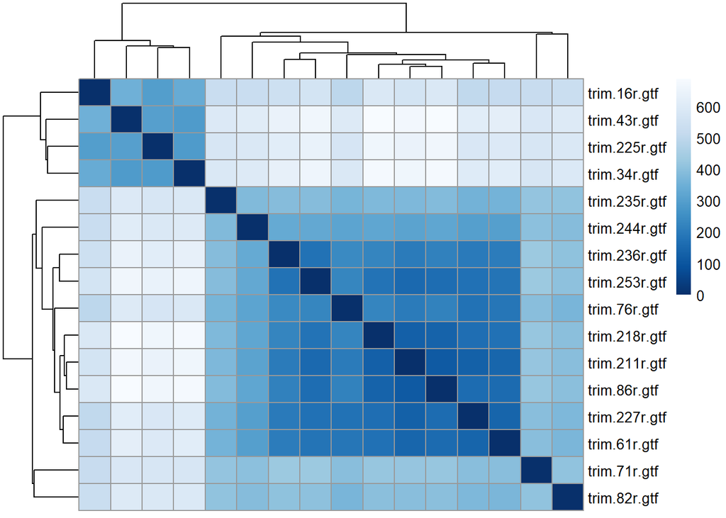

```r
gsampleDists_por <- dist(t(assay(gvst_por))) #calculate distance matix
gsampleDistMatrix_por <- as.matrix(gsampleDists_por) #distance matrix
rownames(gsampleDistMatrix_por) <- colnames(gvst_por) #assign row names
colnames(gsampleDistMatrix_por) <- NULL #assign col names
colors <- colorRampPalette( rev(brewer.pal(9, "Blues")) )(255) #assign colors
save_pheatmap_pdf <- function(x, filename, width=7, height=7) {
  stopifnot(!missing(x))
  stopifnot(!missing(filename))
  pdf(filename, width=width, height=height)
  grid::grid.newpage()
  grid::grid.draw(x$gtable)
  dev.off()
}

pht_por<-pheatmap(gsampleDistMatrix_por, #plot matrix
              clustering_distance_rows=gsampleDists_por, #cluster rows
              clustering_distance_cols=gsampleDists_por, #cluster columns
              col=colors) #set colors
```

```r
save_pheatmap_pdf(pht_por, "figures/porites/sample_distances_por.pdf")
```

```r
dev.off()
```

#Looking at the dispersion/variance of samples using perm_disp prior to sample removal

```r
condition_por <- colData(gdds_por)$eatenvscontrol

# Run the PERMDISP test using the distance matrix and condition
permdisp_result_por <- betadisper(gsampleDists_por, condition_por)

# View the summary of PERMDISP result
summary(permdisp_result_por)
```

```
##                 Length Class  Mode
## eig              15    -none- numeric
## vectors         240    -none- numeric
## distances        16    -none- numeric
## group            16    factor numeric
## centroids        30    -none- numeric
## group.distances   2    -none- numeric
## call              3    -none- call
```

```r
# Step 2: Perform an ANOVA on the betadisper result
permdisp_anova_por <- anova(permdisp_result_por)

# Step 3: Extract the p-value from the ANOVA result
p_value_por <- permdisp_anova_por$`Pr(>F)`[1]

# Step 4: Print the p-value
print(p_value_por)
```

```
## [1] 0.003650602
```

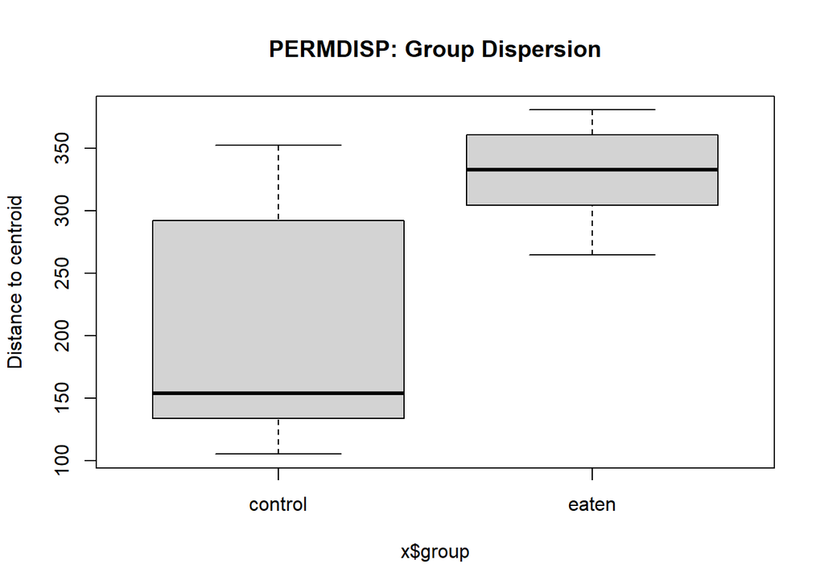

```r
# 0.003650602 = significant difference

# Plot PERMDISP result (dispersion by group)
boxplot(permdisp_result_por, main = "PERMDISP: Group Dispersion")
```

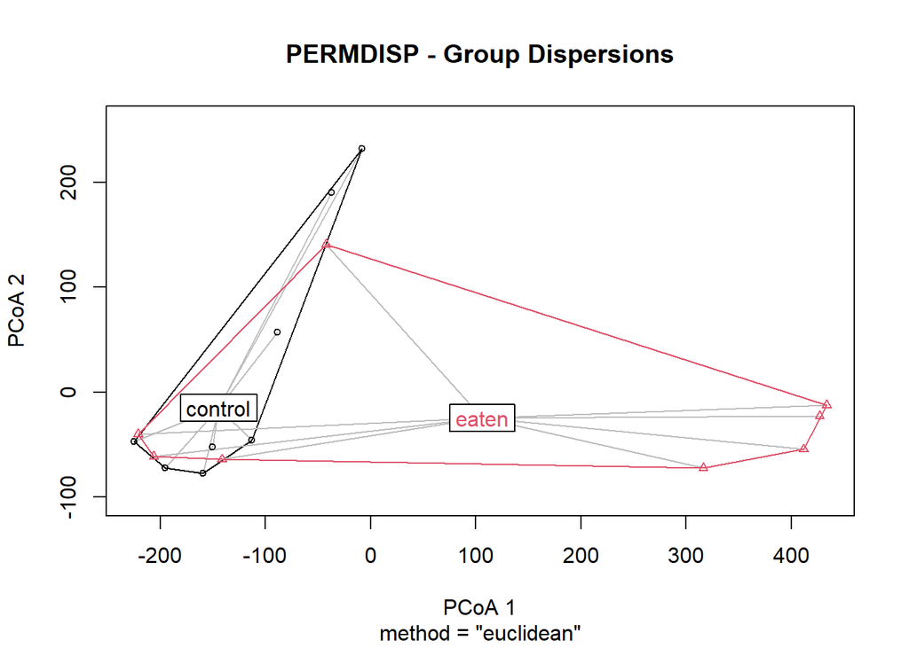

```r
# Optionally, use a scatter plot to see dispersion
plot(permdisp_result_por, main = "PERMDISP - Group Dispersions")
```

# Conduct PERMANOVA for all genes

```r
#Export data for PERMANOVA test.
test_por<-t(assay(gvst_por)) #export as matrix
test_por<-as.data.frame(test_por)

#add category columns
test_por$sample<-rownames(test_por)
test_por$eatenvscontrol<-metadata_por$eatenvscontrol[match(test_por$sample, metadata_por$sample)]

#Build PERMANOVA model for all genes in the dataset.
dim(test_por)
```

```
## [1]    16 16281
```

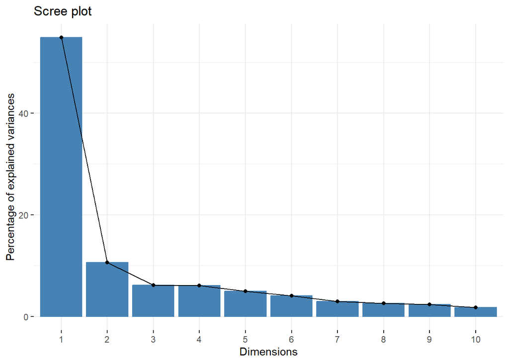

```r
scaled_test_por <-prcomp(test_por[c(1:16279)], scale=TRUE, center=TRUE)
fviz_eig(scaled_test_por)
```

```r
# scale data
vegan_por <- scale(test_por[c(1:16279)])

# PerMANOVA
permanova_por<-adonis2(vegan_por ~ eatenvscontrol, data = test_por, method='eu')
permanova_por
```

```
## Permutation test for adonis under reduced model
## Permutation: free
## Number of permutations: 999
##
## adonis2(formula = vegan_por ~ eatenvscontrol, data = test_por, method = "eu")
##          Df SumOfSqs     R2      F Pr(>F)
## Model     1    38800 0.1589 2.6448  0.061 .
## Residual 14   205385 0.8411
## Total    15   244185 1.0000
## ---
## Signif. codes:  0 '***' 0.001 '**' 0.01 '*' 0.05 '.' 0.1 ' ' 1
```

# Plot a PCA

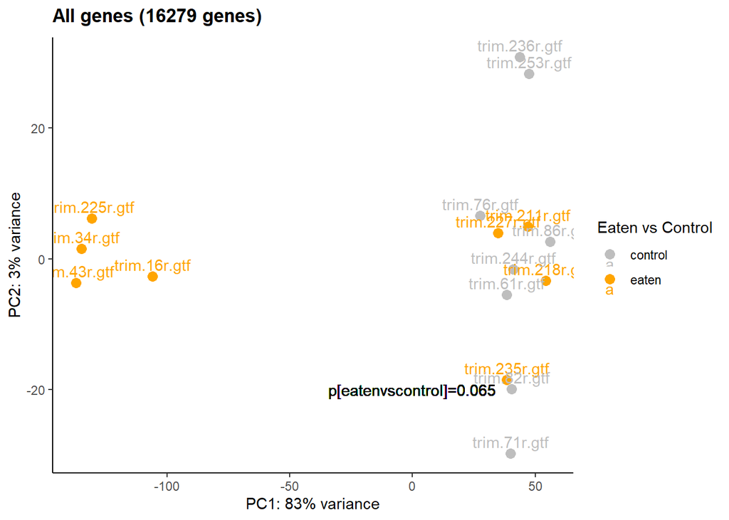

```r
gPCAdata_por <- plotPCA(gvst_por, intgroup = c("eatenvscontrol"), returnData=TRUE)
percentVar_por <- round(100*attr(gPCAdata_por, "percentVar")) #plot PCA of samples with all data

allgenesfilt_PCA_por <- ggplot(gPCAdata_por, aes(PC1, PC2, color=eatenvscontrol)) +
  geom_point(size=3) +
  ggtitle(expression(bold("All genes (16279 genes)")))+
  geom_text(aes(x = PC1, y = PC2, label = name), vjust = -0.5) +
  xlab(paste0("PC1: ",percentVar_por[1],"% variance")) +
  ylab(paste0("PC2: ",percentVar_por[2],"% variance")) +
  scale_color_manual(name="Eaten vs Control", values=c("control"="gray", "eaten"="orange"))+
  geom_text(x=0, y=-20, label="p[eatenvscontrol]=0.065", color="black")+
  theme_classic() + #Set background color
  theme(panel.border = element_blank(), # Set border
        #panel.grid.major = element_blank(), #Set major gridlines
        #panel.grid.minor = element_blank(), #Set minor gridlines
        axis.line = element_line(colour = "black"), #Set axes color
        plot.background=element_blank()); allgenesfilt_PCA_por
```

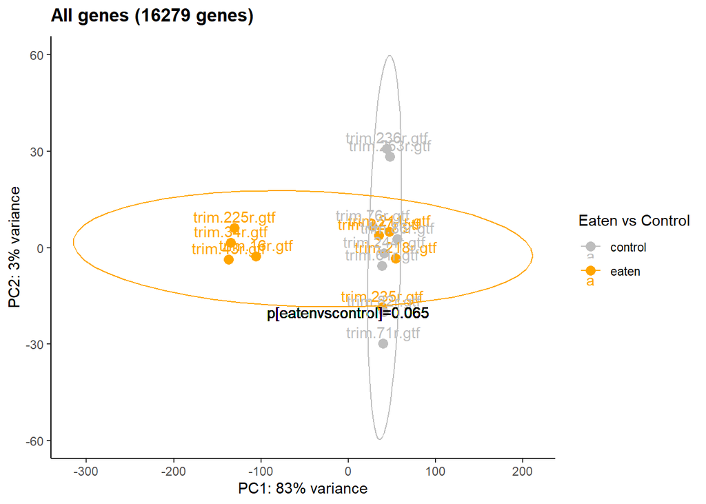

```r
ggsave("figures/porites/pca_por.pdf", allgenesfilt_PCA_por, width=8, height=4)
ggsave("figures/porites/pca_por.jpeg", allgenesfilt_PCA_por, width=8, height=4)

#Add a plot with elipses.
allgenes_ellipse_por<-allgenesfilt_PCA_por + stat_ellipse();allgenes_ellipse_por
```

```r
ggsave("figures/porites/pca_ellipse_por.pdf", allgenes_ellipse_por, width=9, height=5)
ggsave("figures/porites/pca_ellipse_por.jpeg", allgenes_ellipse_por, width=9, height=5)
```

Remove left cluster as it is clusering only based on read depth (225R, 34R, 43R, 16R)

# Filter to remove low read depth samples

Remove 225R, 34R, 43R and 16R from metadata

```r
metadata_por2 <- metadata_por[c(-1, -4, -10, -11), ]
```

Remove 225R, 34R, 43R and 16R from gene count matrix.

```r
#Remove 497R
gcount_por2 <- gcount_por[,c(-1, -4, -10, -11)]
```

Re-run code with removed samples (225R, 34R, 43R and 16R)

```r
dim(gcount_por2)
```

```
## [1] 35599    12
```

```r
gcount_por2<-gcount_por2 %>%
  mutate(Total = rowSums(.[, 1:12]))%>%
  filter(!Total==0)%>%
  dplyr::select(!Total)
dim(gcount_por2)
```

```
## [1] 35577    12
```

Started with 35599 genes, ended with 35577 genes.

# Filtering with pOver A after removing low quality samples

pOver A 4/12=0.33 (round to 0.34 )

```r
#Create filter for the counts data
filt_por2 <- filterfun(pOverA(0.34,10))
gfilt_por2 <- genefilter(gcount_por2, filt_por2)
#identify genes to keep by count filter
gkeep_por2 <- gcount_por2[gfilt_por2,]
#identify gene lists
gn.keep_por2 <- rownames(gkeep_por2)
#gene count data filtered in PoverA, P percent of the samples have counts over A
gcount_filt_por2 <- as.data.frame(gcount_por2[which(rownames(gcount_por2) %in% gn.keep_por2),])

#How many rows do we have before and after filtering?
nrow(gcount_por2) #Before
```

```
## [1] 35577
```

```r
nrow(gcount_filt_por2) #After
```

```
## [1] 22214
```

We had 35577genes before filtering and now have 22214 genes remaining after filtering.